# Example_analysis

## 2. Total Expenditures/Revenue for Each State

**Analysis Question** Q. Are there positive correlation between total expenditures and total revenue in sports for students in US schools?

```r
sports_df %>%
  split(.$state) %>%
  map(~ lm(revenue ~ expend, data=.)) %>%
  map(summary) %>%
  map_dbl("r.squared")
```

[output not shown]

In terms of `r.squared` statistics in simple linear regression, We can observe that there is a significant linear correlation bewteen those two.

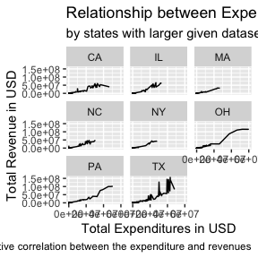

```r
top10 <- sports_df %>%
  group_by(state) %>%
  summarise(count=n())%>%
  top_n(n=8, wt = count) %>%
  select("state")

sports_df %>%
  filter(state %in% top10$state) %>%
  ggplot(aes(x=expend, y = revenue)) +
  geom_line()+
  facet_wrap(~state) +
  xlab("Total Expenditures in USD") +
  ylab("Total Revenue in USD") +
  labs(title = "Relationship between Expenditures and Revenue for sports in US",
       subtitle = "by states with larger given dataset",
       caption = "There is a positive correlation between the expenditure and revenues")
```

## 3. MLE estimates for Expenditures/Revenue

**Analysis Question** Q. What is the estimated density of each expenditure and revenue for all collegiate sports in United States?

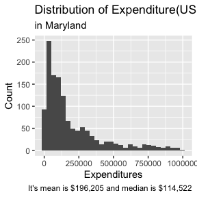

```r
sports_df %>%
  filter(state== "MD", expend < 1000000) %>%
  ggplot(aes(x=expend)) +
  geom_histogram() +
  xlab("Expenditures") +
  ylab("Count") +
  labs(title = "Distribution of Expenditure(USD) in Collegial Sports",
       subtitle = "in Maryland",
       caption = "It's mean is $196,205 and median is $114,522")
```

Distribution of Expenditures in Maryland Collegial sports is right-skewed with mean value $196,205.

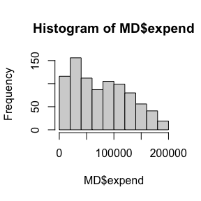

```r
MD <- sports_df %>% filter(state== "MD", expend < 200000, revenue < 200000)
hist(MD$expend)
```

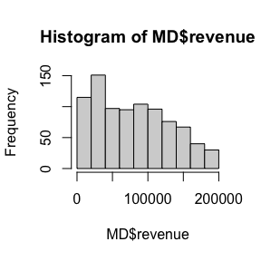

```r
hist(MD$revenue)
```

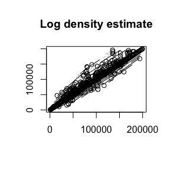

```r
MD_df = cbind(MD$expend,MD$revenue)
lcd <- mlelcd(MD_df)
g <- interplcd(lcd)
plot(lcd, g=g, type="c", uselog=TRUE)
```

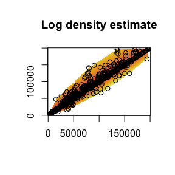

```r
plot(lcd, g=g, type="i", uselog=TRUE)
```

We only selected data from Maryland data without too large values to avoid outliers and maintain log-concave distribution.

We can observe how are 2-dimensional density of Expenditures/Revenue distributed using `LogConcDEAD`. It shows elliptical distribution centered in its mean value.

## 4. List of Functions

### dplyr

- filter()
- mutate()
- select()
- rename()
- group_by()
- summarise()

### purrr

- map()
- map_dbl()

### ggplot2

- geom_bar()
- geom_line()
- geom_histogram()
- facet_wrap()

### LogConcDEAD

- mlelcd()
- interplcd()